# Workshop: Data Management & Visualization in `R` for Biology

Johniel E. Babiera

2025-04-14

## Introduction

### Why `R` for Biology?

**Reproducible Research**

Biology increasingly relies on data-driven workflows (e.g., genomics, ecology, bioinformatics). `R` enables reproducible science:

- Scripts document every step of analysis (no more “black box” Excel formulas).
- Combine code, text, and results in **`R` Markdown** or **Quarto** for publication-ready reports.
- Critical for peer review, collaboration, and future lab members who need to replicate your work.

**Ecosystem of Biology-Specific Tools**

`R` has unparalleled packages for biological research:

- **Bioconductor:** A repository for genomic data analysis (e.g., RNA-seq, DNA methylation, single-cell sequencing). Example, `DESeq2` for differential gene expression.
- **Phylogenetics:** `ape`, `phyloseq`, and `ggtree` for evolutionary trees and microbiome data.
- **Ecology:** `vegan` for community ecology, `raster` for spatial data.

**Data Visualization**

Biology thrives on clear visuals for complex data:

- **`ggplot2`:** Create publication-quality plots (e.g., heatmaps, PCA plots, boxplots).
- **Specialized plots:** Volcano plots (genomics), NMDS plots (ecology), phylogenetic trees.
- Customizable themes for journal formatting requirements.

**Statistical Power**

`R` is built by statisticians, making it ideal for:

- Hypothesis testing (t-tests, ANOVA, GLMs).
- Advanced modeling (mixed-effects models, survival analysis).
- Bioinformatics tools (e.g., `limma` for microarray data).

**Handling Large, Messy Data**

- `dplyr` and `tidyr` (part of the tidyverse) clean and wrangle data efficiently.
- Read large files (e.g., sequencing data) `faster` with `data.table` or `readr`.
- Avoid Excel’s limitations (row limits, accidental data corruption).

**Open Source & Community-Driven**

- Free for students and labs with limited budgets.
- Active communities (e.g., Bioconductor, Stack Overflow) for troubleshooting.
- Continuous updates and cutting-edge tools (e.g., AI/ML integration via `tidymodels`).

**Integration with Other Tools**

- Use `R` with Python via `reticulate`.
- Connect to databases (SQL) or cloud platforms.
- Automate workflows (e.g., `Snakemake` for pipelines).

### Example Workflow in Biology

1. **Import:** Read counts with Bioconductor’s `tximport`.
2. **Analyze:** Differential expression with `DESeq2`.
3. **Visualize:** Volcano plots with `ggplot2`.
4. **Report:** Generate a PDF with methods, code, and results using `R` Markdown.

### Real-World Success Stories

- The [**Human Microbiome Project (HMP)**](https://www.hmpdacc.org/hmp/overview/) used `R` for data analysis.
- Journals like *Nature and Science* encourage code submission in `R`.
- Many biology labs now require `R` skills for PhD candidates.

### Workshop objectives

- Save and load R objects (`.RData`, `.RDS`).
- Read and write data (CSV, Excel, text files).
- Create effective plots (`base R` and `ggplot2`).

## Saving and Loading `R` Objects

**Why save data objects?**

Biologists often work with:

- Large datasets (e.g., gene expression matrices, ecological survey data).
- Computationally intensive models (e.g., `DESeq2`, phylogenetic trees, machine learning outputs).
- Intermediate results that take hours/days to generate.

**Saving objects avoids re-running analyses** and **ensures reproducibility** when sharing with collaborators.

### Multiple Objects

#### Saving Multiple Objects: `.RData` (or `.rda`)

- **Use Case:** Save your entire workspace or a subset of objects (e.g., processed data, models, plots) for later use.
- `save()`: Save multiple `R` objects (e.g., vectors, matrices, models) into a single `.RData` file. Syntax is

```
save(..., file = "filename.RData", envir = parent.frame())
```

- `...`: Names of objects to save (e.g., model, data, matrix).
- `file`: Path/filename for the output.
- `envir`: Environment to search for objects (usually left as default).

**Example 1:** Saving a Linear Model, Vector, and Matrix

Imagine you’re analyzing the relationship between plant growth and sunlight exposure:

```r
# biology data
sunlight <- c(2, 4, 6, 8, 10)  # Hours of sunlight per day
growth <- c(1.2, 2.5, 3.1, 4.0, 4.8)  # Plant growth (cm)

# Run a linear model (simple linear regression)
model_GS <- lm(growth ~ sunlight)

summary(model_GS) # check output


# Create a matrix of experimental conditions
experiment_matrix <- matrix(c(1, 2, 3, 4, 5, 25, 30, 35, 40, 45),
                            ncol = 2,
                            dimnames = list(NULL, c("Day", "Temperature (°C)")))
```

[output not shown]

- To save the entire workspace in the default working directory:

```r
# Save ALL objects to .RData
save(sunlight, growth, model_GS, experiment_matrix, file = "plant_experiment.RData")
```

- To save the entire workspace in the designated path e.g. `D:/RWorkshop`

```r
# Save ALL objects to .RData
save(sunlight, growth, model_GS, experiment_matrix, file = "D:/RWorkshop/plant_experiment.RData")
```

We can check our directory and see the saved file

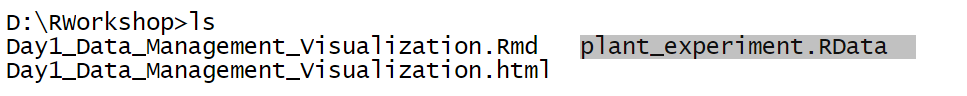

- To save some multiple objects, say `sunlight`, `growth` and `experiment_matrix`, and name the file as `PlantData.RData`:

```r
save(sunlight, growth, experiment_matrix, file = "D:/RWorkshop/PlantData.RData")
```

#### Loading `.RData` or `.rda`

`load()`: Load `.RData` or `.rda` objects into the current workspace. Syntax is

```
load(file, envir = parent.frame(),verbose = FALSE)
```

- `file`: Path/filename of the file to load.
- `envir`: The environment where the data should be loaded (usually left as default).
- `verbose`: Should item names be printed during loading? (usually left as default)

If we want to load the saved file from Example 1, we have

```r
load("plant_experiment.RData")

# check the objects from the save file
ls()
```

```
## [1] "experiment_matrix" "growth"            "model_GS"
## [4] "sunlight"
```

```r
# check the model output
summary(model_GS)
```

```
##
## Call:
## lm(formula = growth ~ sunlight)
##
## Residuals:
##     1     2     3     4     5
## -0.18  0.25 -0.02  0.01 -0.06
##
## Coefficients:
##             Estimate Std. Error t value Pr(>|t|)
## (Intercept)  0.51000    0.19053   2.677 0.075253 .
## sunlight     0.43500    0.02872  15.145 0.000625 ***
## ---
## Signif. codes:  0 '***' 0.001 '**' 0.01 '*' 0.05 '.' 0.1 ' ' 1
##
## Residual standard error: 0.1817 on 3 degrees of freedom
## Multiple R-squared:  0.9871, Adjusted R-squared:  0.9828
## F-statistic: 229.4 on 1 and 3 DF,  p-value: 0.000625
```

**Caveats:**

- Objects overwrite existing ones in your workspace with the same names.
- Avoid accidentally cluttering your workspace with unneeded objects.

### Single Objects

#### Saving Single Objects

- **Use Case:** Save a single object (e.g., a large phylogenetic tree, a model, a processed dataframe) efficiently.
- `saveRDS()`: Save a single `R` object (e.g., a model, matrix, vector) in a compressed format. Syntax is

```
saveRDS(object, file = "filename.RDS", compress = TRUE)
```

- `object`: The object to save (e.g., model, matrix, list).
- `compress`: Reduce file size (default: TRUE).

**Example 2:** Saving a Linear Regression Model

Let’s say we are working about Butterfly data

```r
# Simulate data: Butterfly wing length vs. body size
body_size <- c(12, 15, 18, 20, 22)  # Body length (mm)
wing_length <- c(25, 30, 35, 40, 45)  # Wing length (mm)

# Run a linear model
butterfly_model <- lm(wing_length ~ body_size)
summary(butterfly_model)
```

```
##
## Call:
## lm(formula = wing_length ~ body_size)
##
## Residuals:
##       1       2       3       4       5
##  0.6804 -0.2532 -1.1867 -0.1424  0.9019
##
## Coefficients:
##             Estimate Std. Error t value Pr(>|t|)
## (Intercept)   0.5854     2.1462   0.273 0.802721
## body_size     1.9778     0.1208  16.366 0.000496 ***
## ---
## Signif. codes:  0 '***' 0.001 '**' 0.01 '*' 0.05 '.' 0.1 ' ' 1
##
## Residual standard error: 0.9607 on 3 degrees of freedom
## Multiple R-squared:  0.9889, Adjusted R-squared:  0.9852
## F-statistic: 267.9 on 1 and 3 DF,  p-value: 0.0004964
```

To save this model, we have:

```r
# Save the model as .RDS
saveRDS(butterfly_model, file = "butterfly_model.RDS")
```

**Example 3**: Saving Species Abundance Matrix

```r
# Simulate species abundance matrix
abundance_matrix <- matrix(c(10, 5, 15, 20),
                           nrow = 2,
                           dimnames = list(c("Site_A", "Site_B"),
                                          c("Species_X", "Species_Y")))

abundance_matrix
```

```
##        Species_X Species_Y
## Site_A        10        15
## Site_B         5        20
```

To save, we have:

```r
# Save the matrix
saveRDS(abundance_matrix, file = "species_abundance.RDS")
```

#### Reading/Loading `.RDS` object

`readRDS()`: Read an `.RDS` object. The syntax is

```
readRDS(file)
```

- `file`: Path/filename of the file to load.

For example. to read the `.RDS` file (model) of from Example 2 and store it in a named object, say `butterfly_model_result`, we have

```r
butterfly_model_result <- readRDS("butterfly_model.RDS")
summary(butterfly_model_result)
```

```
##
## Call:
## lm(formula = wing_length ~ body_size)
##
## Residuals:
##       1       2       3       4       5
##  0.6804 -0.2532 -1.1867 -0.1424  0.9019
##
## Coefficients:
##             Estimate Std. Error t value Pr(>|t|)
## (Intercept)   0.5854     2.1462   0.273 0.802721
## body_size     1.9778     0.1208  16.366 0.000496 ***
## ---
## Signif. codes:  0 '***' 0.001 '**' 0.01 '*' 0.05 '.' 0.1 ' ' 1
##
## Residual standard error: 0.9607 on 3 degrees of freedom
## Multiple R-squared:  0.9889, Adjusted R-squared:  0.9852
## F-statistic: 267.9 on 1 and 3 DF,  p-value: 0.0004964
```

**Key Advantage:** We control the object’s name when loading (no risk of overwriting).

### Summary

Comparison of Functions

| Function | Use Case | File Type | Objects Saved | Key Feature |
| --- | --- | --- | --- | --- |
| `save()` | Multiple objects | `.RData` | Multiple | Saves workspace snapshots |
| `load()` | Load `.RData` files | `.RData` | Multiple | Restores workspace objects |
| `saveRDS()` | Single object | `.RDS` | Single | Space-efficient, compressed |
| `readRDS()` | Load `.RDS` files | `.RDS` | Single | Explicit object assignment |

## `R` Packages

`R` packages are collections of functions, data, and documentation that extend `R`’s capabilities. They are like “toolboxes” tailored for specific tasks, enabling users to:

- Standardize workflows (e.g., ggplot2 for plotting).
- Share code with the community.
- Solve domain-specific problems (e.g., Bioconductor for genomics).

For users, packages eliminate the need to reinvent the wheel, providing tested and optimized tools for tasks like statistical analysis, data visualization, and genomic data processing.

### The `R` Package Ecosystem

A. Repositories 1. **[CRAN (Comprehensive R Archive Network)](https://cran.r-project.org/)**: - Primary repository for general-purpose packages (e.g., dplyr, ggplot2). - Strict quality checks ensure reliability.

2. Bioconductor: - Specialized repository for genomics, proteomics, and bioinformatics. - Packages like `DESeq2` (RNA-seq analysis) and `GenomicRanges` (genomic intervals). - Releases occur every 6 months for compatibility.
3. GitHub: - Hosts cutting-edge or niche packages not yet on CRAN/Bioconductor. - Install via `remotes::install_github("user/repo")`.
2. Popular Package Categories for Biology

| Category | Example Packages | Use Case |
| --- | --- | --- |
| Data Wrangling | `dplyr`, `tidyr` | Clean and reshape data (e.g., species counts). |
| Genomics | `DESeq2`, `limma` | Differential gene expression analysis. |
| Ecology | `vegan`, `ade4` | Community ecology (e.g., diversity indices). |
| Phylogenetics | `ape`, `ggtree` | Build and visualize evolutionary trees. |
| Visualization | `ggplot2`, `ComplexHeatmap` | Create publication-ready plots. |

### Installing and Loading Packages

**CRAN (Comprehensive R Archive Network)** is the primary repository for general-purpose `R` packages (e.g., `dplyr`, `ggplot2`). The syntax is

```
install.packages("package_name")
```

Example

```r
install.packages("tidyverse")  # Installs dplyr, ggplot2, readr, etc.
```

For installation of multiple packages, use `c()`, for example

```
install.packages(c("dplyr", "ggplot2", "tidyr"))
```

** Bioconductor Packages**

- To install packages from [Bioconductor](https://www.bioconductor.org/about/), we have to get the latest version of Bioconductor:

```r
# install the Biocmanager
if (!require("BiocManager", quietly = TRUE))
  install.packages("BiocManager")

#BiocManager::install(version = "3.21")
```

- To install core packages, we have

```r
BiocManager::install(c("GenomicFeatures", "AnnotationDbi"))
```

- To install specific package, say `DESeq2`

```r
BiocManager::install("DESeq2")
```

**GitHub Packages**

To install from GitHub, we use the following syntax:

```
remotes::install_github("username/repository_name")
```

Key Rules:

- Slash `/`: Separates the GitHub username and repository (e.g., “`tidyverse/ggplot2`”).
- Branches/Tags: Specify versions with `@` (e.g., “user/repo@v1.0”).

Example (Ecology): Install a development version of a niche ecology package:

```r
# install first the remotes
install.packages("remotes")
# For handling Open Data Kit surveys
remotes::install_github("ropensci/ruODK")
```

### Loading Packages

To load a package, we use the syntax

```
library(package_name)  # No quotes needed
```

Key Rules:

- No Quotes: Use `library(dplyr)`, not `library("dplyr")` (though quotes are optional).
- Conflict Resolution: Use `package::function()` to specify the package (e.g., `dplyr::filter()`).

## Input and Output: Reading and Writing Data

### Reading Data into `R`

#### CSV Files (Comma-Separated Values)

- Spreadsheet data from lab experiments, field surveys, or public repositories.
- `read.csv()`: Use to read CSV file. The syntax is

```
read.csv(file, header = TRUE, sep = ",", quote = "\"",
         dec = ".", fill = TRUE, ...)
```

- `file`: Path/filename of the csv file to read.
- `header`: A logical value indicating whether the file contains the names of the variables as its first line. If missing, the value is determined from the file format: `header` is set to `TRUE` if and only if the first row contains one fewer field than the number of columns.
- `sep`: The field separator character. Values on each line of the file are separated by this character.
- `quote`: The set of quoting characters.
- `dec`: The character used in the file for decimal points.
- `fill`: A logical value. If `TRUE` then in case the rows have unequal length, blank fields are implicitly added.
- `...`: Other arguments

**Example 4:** Consider the `species_counts.csv` data inside the Data folder in our working directory. To load this data, we have

```r
species_count <- read.csv("Data/species_counts.csv",header = T,
                          sep=",")
# check the first 5 rows
head(species_count)
```

```
##       Site Oak Pine Birch
## 1 Forest_A  25   12     5
## 2 Forest_B  18   20    15
## 3 Forest_C  30    8    10
```

#### Excel Files

- **Use Case:** Data collected in Excel from lab equipment or collaborators.
- `readxl`: Use to get data out of Excel and into `R`. It supports both the legacy `.xls` format and the modern xml-based `.xlsx` format. The easiest way to install the latest released version from CRAN is to install the whole `tidyverse.`

```r
install.packages("tidyverse")

# Alternatively, install just readxl from CRAN:
install.packages("readxl")
```

**Example 5**: Import the data from sheet 1 of `plant_growth.xlsx` inside our Data folder. To load,

```r
library(readxl)

# Read the first sheet
data_PlandGrowth <- read_excel("Data/plant_growth.xlsx",sheet = "Sheet1")

# check first 6 rows
head(data_PlandGrowth)
```

```
## # A tibble: 6 × 3
##   Treatment  Height_cm Leaf_Area
##   <chr>          <dbl>     <dbl>
## 1 Control           10        30
## 2 Control           12        32
## 3 Control           11        31
## 4 Control           13        33
## 5 Control           14        34
## 6 Fertilizer        22        45
```

#### Text/TSV Files (Tab-Separated Values)

- **Use Case:** Output from sequencing machines, environmental sensors, or GIS tools.
- `read.delim2()`: Use to import general text tabular data by specifying the delimiter. We can also use `read.table()` for more generic function.

**Example 6**: Load the DNA sequence data `dna_sequences.txt`. Values are separated by tab (`"\t"`).

```r
dna_data <- read.delim2("Data/dna_sequences.txt", header = TRUE, sep = "\t")
print(dna_data)
```

```
##   SampleID   Sequence Length
## 1       S1 ATGCTAGCTA     10
## 2       S2 TGCTAGCTAG     10
## 3       S3 GCTAGCTAGC     10
```

### Writing Data from `R`

1. **CSV Files:** We use

```
write.csv(data, file, row.names=F,...)
```

- `data`: The data to be written, preferably a matrix or data frame.
- `file`: Path/filename
- `row.names`: A logical value whether to include row names or not.
- `...`: Other arguments like `sep` for delimiters, `col.names` , etc.

**Example 7**: Write the following data into a CSV format inside the Data folder in the working directory.

```r
species_data_2 <- data.frame(
  Site = c("Site_A", "Site_B", "Site_C"),
  Oak = c(35, 28, 40),
  Pine = c(22, 30, 18),
  Birch = c(15, 25, 20)
)
species_data_2
```

```
##     Site Oak Pine Birch
## 1 Site_A  35   22    15
## 2 Site_B  28   30    25
## 3 Site_C  40   18    20
```

```r
# save as CSV
write.csv(species_data_2,"Data/species_counts2.csv", row.names = FALSE)
```

2. **Excel Files:** [`writexl`](https://cran.r-project.org/web/packages/writexl/writexl.pdf) package has a function `write_xlsx` that write a data frame to an `xlsx` file.

[output not shown]

**Example 8**: Write the `species_data_2` and `species_data_3` (below) into a single Excel file. Name the sheet containing the `species_data_2` as “my_data1” and the sheet containing `species_data_3` with “my_data2”.

```r
species_data_3 <- data.frame(
  Site = c("Site_A", "Site_B", "Site_C"),
  Oak = c(30, 23, 43),
  Pine = c(20, 32, 8),
  Birch = c(10, 26, 21)
)
species_data_3
```

```
##     Site Oak Pine Birch
## 1 Site_A  30   20    10
## 2 Site_B  23   32    26
## 3 Site_C  43    8    21
```

```r
# writing to Excel
writexl::write_xlsx(list("my_data1" = species_data_2,
                         "my_data2" = species_data_3),
                    path = "Data/Species_Count.xlsx")
```

3. Text/TSV Files

We can use the syntax:

```
write.table(data, file = "",sep = " ", row.names = TRUE)
```

to write `R` object in a text file.

- `data`: The data to be written, preferably a matrix or data frame.
- `file`: Path/filename
- `row.names`: A logical value whether to include row names or not.
- `...`: Other arguments like `sep` for delimiters, `col.names` , etc.

**Example 9**: Write the `species_data_2` into a semicolon (;) separated values text file .

```r
# save as CSV
write.table(species_data_2,"Data/species_counts2.txt", sep = ";",
            row.names = FALSE)
```

### More of `Tidyverse` Data import

Here is a [cheatsheet](https://github.com/rstudio/cheatsheets/blob/main/data-import.pdf) develop by Tidyverse Team

## Plots and Graphs

### Base `R` Plotting

Base `R` uses function-based plotting, where each plot type (scatter, boxplot, etc.) has its own function. Plots are built incrementally by adding arguments or layers. The general syntax is

```
plot_function(
  x,                      # X-axis data (vector or formula)
  y,                      # Y-axis data (optional)
  data = NULL,            # Data source if X is a formula
  main = "Title",         # Plot title
  xlab = "X Label",       # X-axis label
  ylab = "Y Label",       # Y-axis label
  col = "color",          # Color (points, lines, bars)
  pch = 16,               # Point symbol (16 = filled circle)
  type = "p",             # Plot type ("p" = points, "l" = lines)
  ...                     # other arguments for plotting
)
```

For parameter `type`, we have the following choices

- “p” for points,
- “l” for lines,
- “b” for both,
- “c” for the lines part alone of “b”,
- “o” for both ‘overplotted’,
- “h” for ‘histogram’ like (or ‘high-density’) vertical lines,
- “s” for stair steps (moves horizontal then vertical),
- “S” for other steps (other way around of “s”),
- “n” for no plotting.

Some Key Functions

- `plot()`: Generic plotting (scatter, line, etc.).
- `boxplot()`: Box-and-whisker plots.
- `hist()`: Histograms.
- `barplot()`: Bar plots.
- `points()/lines()`: Add elements to existing plots.

**Scatter Plot:**

Visualizing the relationship between two variables (e.g., plant height vs. sunlight).

**Example 10**: Carbon Dioxide Uptake in Grass Plants

This study is about carbon dioxide uptake in grass species *Echinochloa crus-galli* under different treatments.

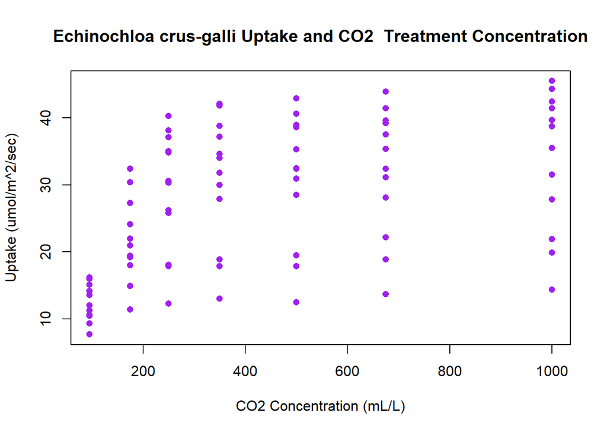

```r
uptake <- CO2$uptake
concetration <- CO2$conc

plot(concetration, uptake,
     main = "Echinochloa crus-galli Uptake and CO2  Treatment Concentration",
     xlab = "CO2 Concentration (mL/L)",
     ylab = "Uptake (umol/m^2/sec)",
     col = "purple", pch = 16)
```

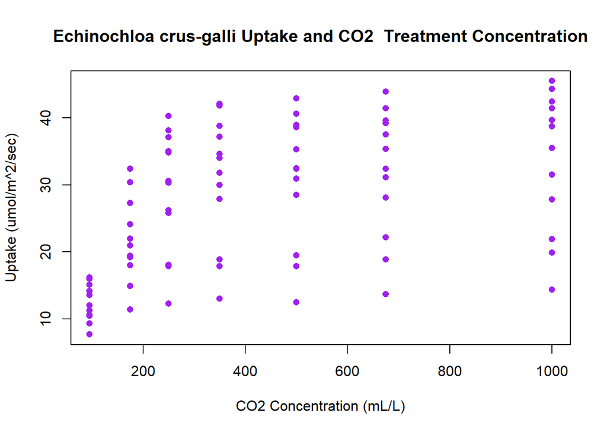

```r
plot(uptake ~ conc, data = CO2,
     main = "Echinochloa crus-galli Uptake and CO2  Treatment Concentration",
     xlab = "CO2 Concentration (mL/L)", ylab = "Uptake (umol/m^2/sec)",
     col = "purple", pch = 16)
```

**Boxplot**

`boxplot(x,...)` produce box-and-whisker plot(s) of the given (grouped) values. To read its syntax and usage, run the following code:

```r
 #search
?boxplot
```

**Example 11:** Edgar Anderson’s Iris Data

This famous (Fisher’s or Anderson’s) iris data set gives the measurements in centimeters of the variables sepal length and width and petal length and width, respectively, for 50 flowers from each of 3 species of iris. The species are Iris setosa, versicolor, and virginica.

Let’s say we are concerned the distribution of Sepal Lenght for each different species of Iris flower.

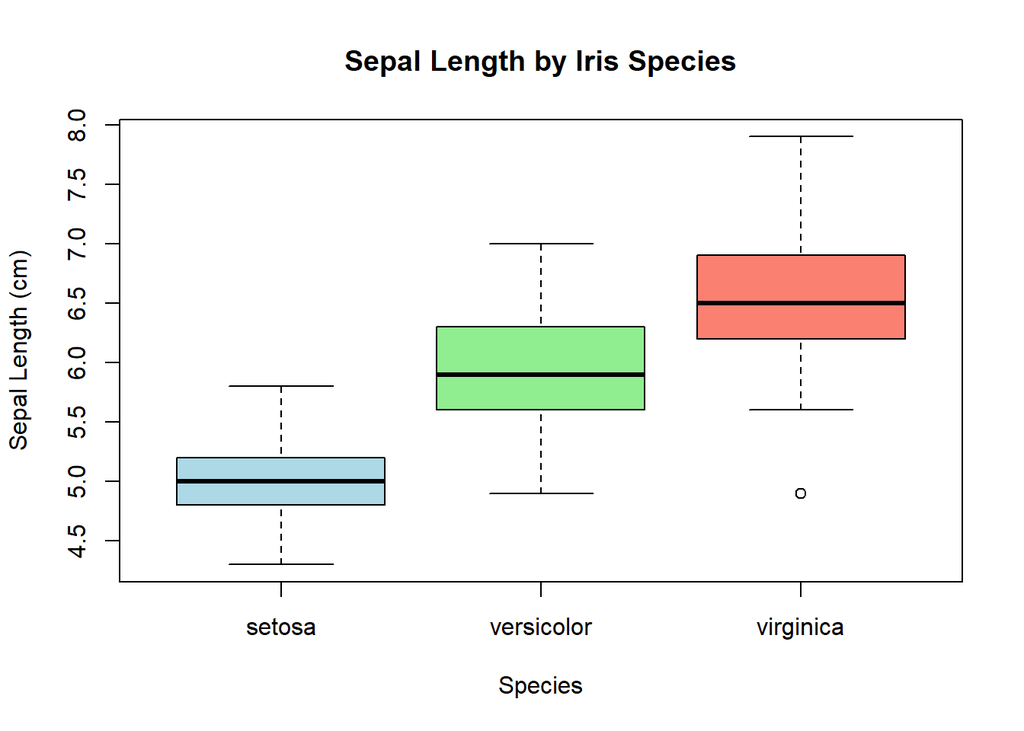

```r
boxplot(Sepal.Length ~ Species, data = iris,
        main = "Sepal Length by Iris Species",
        xlab = "Species",
        ylab = "Sepal Length (cm)",
        col = c("lightblue", "lightgreen", "salmon"))
```

**Histogram**

`hist()` computes a histogram of the given data values. See

```r
?hist
```

for its syntax and usage.

**Example 12:** Weight versus age of chicks on different diets

The `ChickWeight` data frame has 578 rows and 4 columns from an experiment on the effect of diet on early growth of chicks.

Let’s take a look on the final weights:

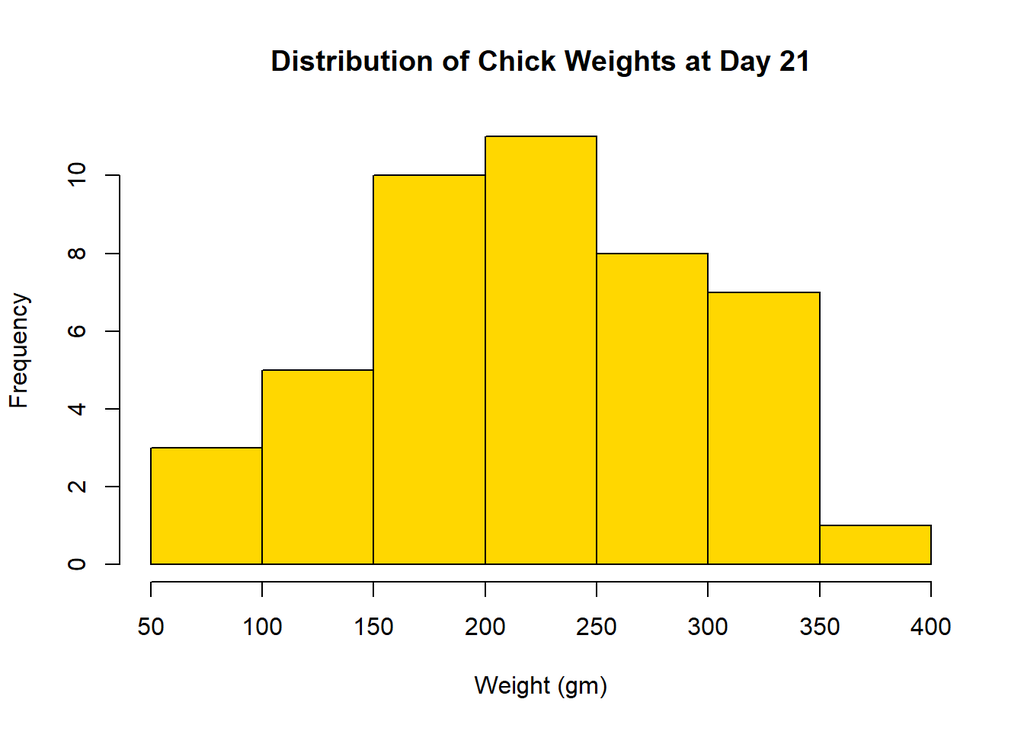

```r
final_weights <- ChickWeight$weight[ChickWeight$Time == 21]
hist(final_weights,
     main = "Distribution of Chick Weights at Day 21",
     xlab = "Weight (gm)", col = "gold", border = "black")
```

Using `nclass` parameter, we can control the number of bins:

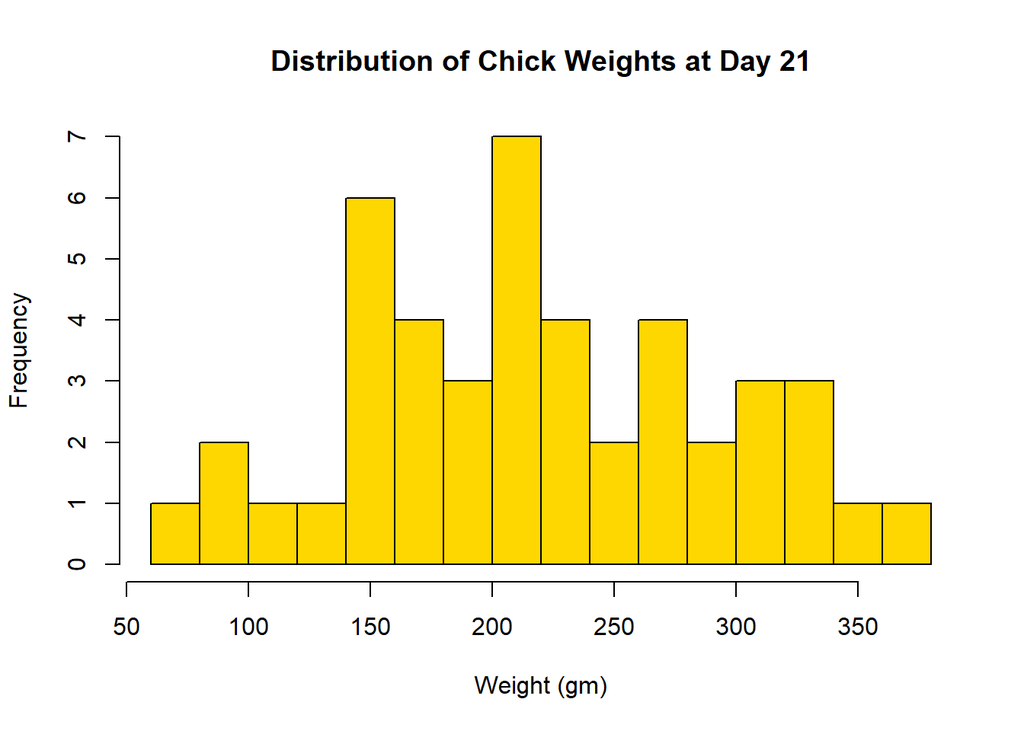

```r
hist(final_weights, nclass = 15,
     main = "Distribution of Chick Weights at Day 21",
     xlab = "Weight (gm)", col = "gold", border = "black")
```

**Barplot**

`barplot()` creates a bar plot with vertical or horizontal bars. The syntax and usage are:

```r
barplot(height, ...)
## Default S3 method:
barplot(height, width = 1, space = NULL,
        names.arg = NULL, legend.text = NULL, beside = FALSE,
        horiz = FALSE, density = NULL, angle = 45,
        col = NULL, border = par("fg"),
        main = NULL, sub = NULL, xlab = NULL, ylab = NULL,
        xlim = NULL, ylim = NULL, xpd = TRUE, log = "",
        axes = TRUE, axisnames = TRUE,
        cex.axis = par("cex.axis"), cex.names = par("cex.axis"),
        inside = TRUE, plot = TRUE, axis.lty = 0, offset = 0,
        add = FALSE, ann = !add && par("ann"), args.legend = NULL, ...)

## S3 method for class 'formula'
barplot(formula, data, subset, na.action,
        horiz = FALSE, xlab = NULL, ylab = NULL, ...)
```

**Example 13:** Edgar Anderson’s Iris Data

Using the `iris` dataset, supposed we wish to compare each species by their average petal length.

```r
# compute the means
means <- aggregate(Petal.Length ~ Species, data = iris, mean)
means
```

```
##      Species Petal.Length
## 1     setosa        1.462
## 2 versicolor        4.260
## 3  virginica        5.552
```

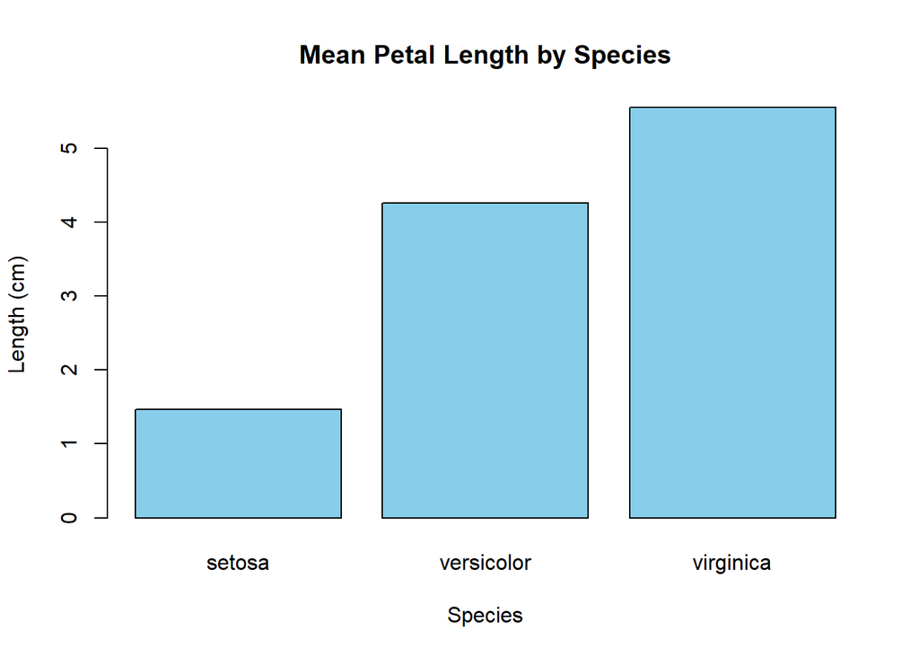

```r
barplot(means$Petal.Length, names.arg = means$Species,
        main = "Mean Petal Length by Species",
        xlab = "Species", ylab = "Length (cm)",
        col = "skyblue")
```

We can use the `horiz=TRUE` option for horizontal:

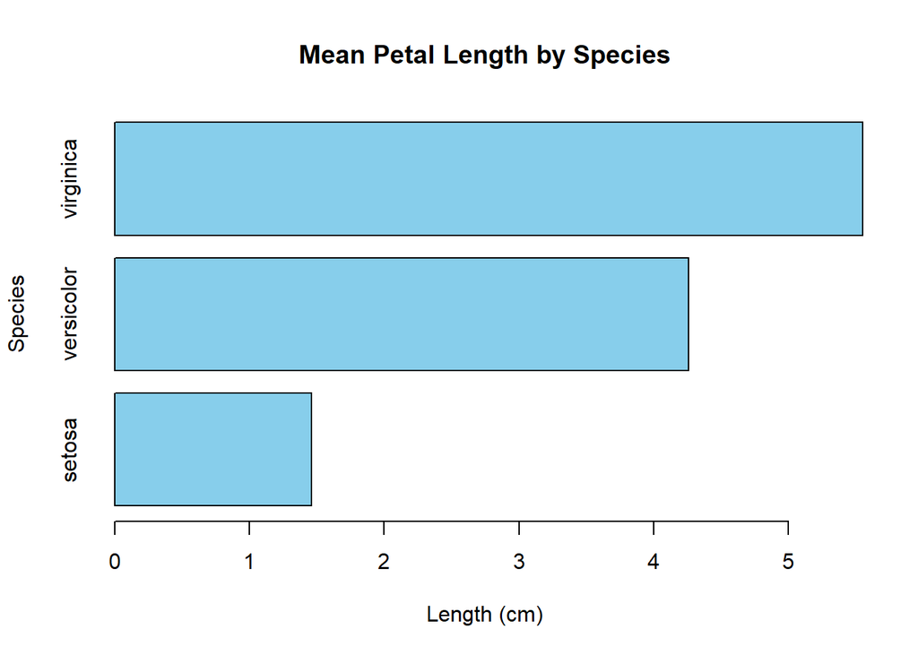

```r
barplot(means$Petal.Length, names.arg = means$Species,
        main = "Mean Petal Length by Species",
        ylab = "Species", xlab = "Length (cm)",
        col = "skyblue",
        horiz = TRUE)
```

**Example 14:** Effect of Vitamin C on Tooth Growth in Guinea Pigs

The response is the length of odontoblasts (cells responsible for tooth growth) in 60 guinea pigs. Each animal received one of three dose levels of vitamin C (0.5, 1, and 2 mg/day) by one of two delivery methods, orange juice or ascorbic acid (a form of vitamin C and coded as VC).

Suppose we want Compare tooth length across different doses (`dose`) and supplements (`supp`).

```r
# Aggregate data to calculate mean tooth length by dose and supplement
agg_data_TG <- aggregate(len ~ dose + supp, data = ToothGrowth, FUN = mean)
agg_data_TG
```

```
##   dose supp   len
## 1  0.5   OJ 13.23
## 2  1.0   OJ 22.70
## 3  2.0   OJ 26.06
## 4  0.5   VC  7.98
## 5  1.0   VC 16.77
## 6  2.0   VC 26.14
```

```r
# Create a matrix for clustered bars
agg_wide_TG <- tidyr::spread(agg_data_TG,key = dose, value = len)
bar_matrix_TG <-as.matrix(agg_wide_TG[,2:4])
rownames(bar_matrix_TG) <- agg_wide_TG$supp
bar_matrix_TG
```

```
##      0.5     1     2
## OJ 13.23 22.70 26.06
## VC  7.98 16.77 26.14
```

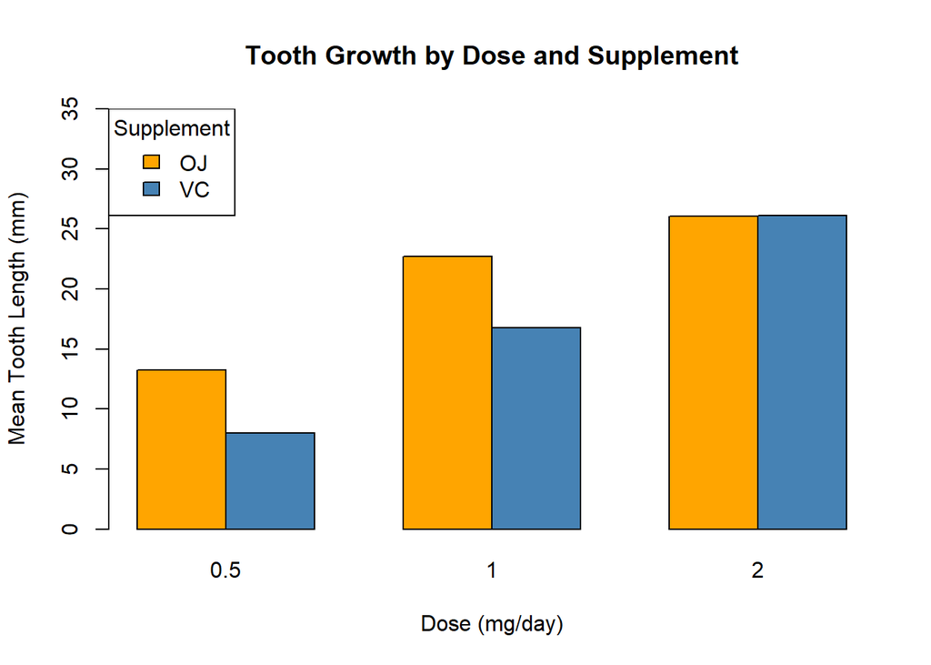

```r
# Plot clustered bars
barplot(bar_matrix_TG,
        beside = TRUE,                  # Cluster bars
        main = "Tooth Growth by Dose and Supplement",
        xlab = "Dose (mg/day)",
        ylab = "Mean Tooth Length (mm)",
        col = c("orange", "steelblue"), # Colors for OJ and VC
        ylim = c(0, 35))

# Add legend
legend("topleft",
       legend = rownames(bar_matrix_TG),
       title = "Supplement",
       fill = c("orange", "steelblue"))
```

**Example 15:** Carbon Dioxide Uptake in Grass Plants

Suppose we want to compare total CO2 uptake across plant types (Type) and treatments (Treatment).

```r
# Aggregate total CO2 uptake by Type and Treatment
agg_data_co2 <- aggregate(uptake ~ Treatment + Type,
                          data = CO2, FUN = sum)

# Create a matrix for stacked bars
agg_wide_co2 <- tidyr::spread(agg_data_co2,key = Type, value = uptake)
bar_matrix_co2 <-as.matrix(agg_wide_co2[,2:3])
rownames(bar_matrix_co2) <- agg_wide_co2$Treatment
bar_matrix_co2
```

```
##            Quebec Mississippi
## nonchilled  742.0       545.0
## chilled     666.8       332.1
```

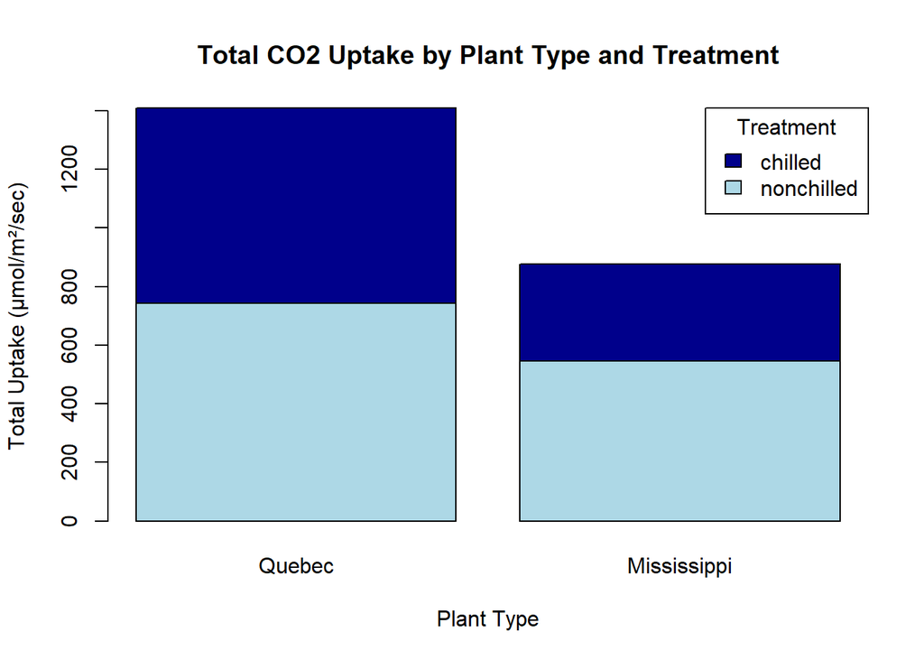

```r
# Plot stacked bars
barplot(bar_matrix_co2,
        beside = FALSE,
        main = "Total CO2 Uptake by Plant Type and Treatment",
        xlab = "Plant Type",
        ylab = "Total Uptake (μmol/m²/sec)",
        col = c("lightblue", "darkblue"), # Colors for treatments
        legend.text = rownames(bar_matrix_co2),
        args.legend = list(title = "Treatment", x = "topright"))
```

**Line Plot**

**Example 16:** Orange Dataset

The `Orange` data frame has 35 rows and 3 columns of records of the growth of orange trees.

Suppose we want to see the growth of the 3rd Orange Tree over time.

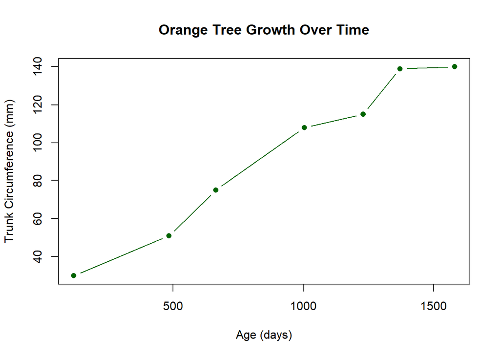

```r
Orange3 <- Orange[Orange$Tree==3,]

plot(circumference ~ age, data = Orange3,
     main = "Orange Tree Growth Over Time",
     xlab = "Age (days)", ylab = "Trunk Circumference (mm)",
     col = "darkgreen", type = "b", pch = 16)
```

### GGPLOT

`ggplot2` is a powerful and flexible package for creating professional, customizable plots.

#### Core Philosophy: The Grammar of Graphics

`ggplot2` uses a layered approach to plotting. We build a plot by combining components like:

1. **Data:** Our dataset (e.g., data.frame).
2. **Aesthetics** (`aes()`): Mapping variables to visual properties (e.g., x, y, color, shape).
3. **Geoms** (`geom_*()`): Geometric objects like points, bars, lines.
4. **Scales** (`scale_*()`): Control axes, colors, legends.
5. **Themes** (`theme()`): Customize non-data elements (fonts, grids).